# Project: Movie Data Analysis

- Introduction
- List of Packages
- Data Wrangling
- Exploratory Data Analysis
- Conclusions

## Introduction

#### The following are the observations we will be doing with this data:

> - What Genre is the most popular
> - The Most Profitable Movie
> - Do Higher Budget Movie Performe Better
> - What Word Is Use The Most In Titles

### List of Packages

> - **Pandas** - To load, clean, manipulate the data
> - **Numpy** - To performe calculation on my data
> - **Matplot** - To have more control and customization over the charts we plot
> - **Seaborn** - To create more aesthetically pleasing charts
> - **Wordcloud** - To Create a word cloud

```python
# import packages
import pandas as pd
import numpy as np
import matplotlib.pyplot as plt
import seaborn as sns
from wordcloud import WordCloud, STOPWORDS, ImageColorGenerator
% matplotlib inline
```

## Data Wrangling

### General Properties

```python
# Load your data

df = pd.read_csv('movies.csv')

df.head()
```

|  | id | imdb_id | popularity | budget | revenue | original_title | cast | homepage | director | tagline | ... | overview | runtime | genres | production_companies | release_date | vote_count | vote_average | release_year | budget_adj | revenue_adj |
| --- | --- | --- | --- | --- | --- | --- | --- | --- | --- | --- | --- | --- | --- | --- | --- | --- | --- | --- | --- | --- | --- |
| 0 | 135397 | tt0369610 | 32.985763 | 150000000 | 1513528810 | Jurassic World | Chris Pratt\|Bryce Dallas Howard\|Irrfan Khan\|Vi... | http://www.jurassicworld.com/ | Colin Trevorrow | The park is open. | ... | Twenty-two years after the events of Jurassic ... | 124 | Action\|Adventure\|Science Fiction\|Thriller | Universal Studios\|Amblin Entertainment\|Legenda... | 6/9/15 | 5562 | 6.5 | 2015 | 1.379999e+08 | 1.392446e+09 |
| 1 | 76341 | tt1392190 | 28.419936 | 150000000 | 378436354 | Mad Max: Fury Road | Tom Hardy\|Charlize Theron\|Hugh Keays-Byrne\|Nic... | http://www.madmaxmovie.com/ | George Miller | What a Lovely Day. | ... | An apocalyptic story set in the furthest reach... | 120 | Action\|Adventure\|Science Fiction\|Thriller | Village Roadshow Pictures\|Kennedy Miller Produ... | 5/13/15 | 6185 | 7.1 | 2015 | 1.379999e+08 | 3.481613e+08 |
| 2 | 262500 | tt2908446 | 13.112507 | 110000000 | 295238201 | Insurgent | Shailene Woodley\|Theo James\|Kate Winslet\|Ansel... | http://www.thedivergentseries.movie/#insurgent | Robert Schwentke | One Choice Can Destroy You | ... | Beatrice Prior must confront her inner demons ... | 119 | Adventure\|Science Fiction\|Thriller | Summit Entertainment\|Mandeville Films\|Red Wago... | 3/18/15 | 2480 | 6.3 | 2015 | 1.012000e+08 | 2.716190e+08 |
| 3 | 140607 | tt2488496 | 11.173104 | 200000000 | 2068178225 | Star Wars: The Force Awakens | Harrison Ford\|Mark Hamill\|Carrie Fisher\|Adam D... | http://www.starwars.com/films/star-wars-episod... | J.J. Abrams | Every generation has a story. | ... | Thirty years after defeating the Galactic Empi... | 136 | Action\|Adventure\|Science Fiction\|Fantasy | Lucasfilm\|Truenorth Productions\|Bad Robot | 12/15/15 | 5292 | 7.5 | 2015 | 1.839999e+08 | 1.902723e+09 |
| 4 | 168259 | tt2820852 | 9.335014 | 190000000 | 1506249360 | Furious 7 | Vin Diesel\|Paul Walker\|Jason Statham\|Michelle ... | http://www.furious7.com/ | James Wan | Vengeance Hits Home | ... | Deckard Shaw seeks revenge against Dominic Tor... | 137 | Action\|Crime\|Thriller | Universal Pictures\|Original Film\|Media Rights ... | 4/1/15 | 2947 | 7.3 | 2015 | 1.747999e+08 | 1.385749e+09 |

5 rows × 21 columns

```python
df.shape
```

```
(10866, 21)
```

## Data Cleaning

> After loading the dataset into a dataframe, I have decide to make some changes to have a clean data to work with.

### Changes:

> - Remove unnecessary columns for the data exploration in this project
> - Convert 'relese_date' column from string type to a datatime
> - Drop rows with missing values
> - Added the profit column
> - Rearrange columns

```python
#Create list for all the columns that are going to be dropped
filter_col = ['cast', 'imdb_id', 'budget_adj', 'revenue_adj','production_companies', 'homepage', 'keywords', 'overview', 'tagline', 'popularity', 'vote_count']
df.drop(filter_col, axis=1, inplace=True)
```

```python
#Checks for duplicates
df.duplicated().sum()
```

```
1
```

```python
#Drops duplicate rows and rows with missing values
df.drop_duplicates(inplace=True)
df.dropna(inplace=True)
```

```python
#We use pandas to_datatime to convert the release_date colmun to datime object
df['release_date'] = pd.to_datetime(df.release_date)
```

```python
#Here we substract the budget from the revenue to get the profit generated from the movie
df['profit'] = df.revenue - df.budget
```

```python
#col is a list of the columns in the order that they are going to be reindex
col = ['id', 'original_title', 'director', 'runtime', 'genres', 'budget', 'revenue', 'profit', 'release_date', 'vote_average']
df = df.reindex(columns=col)
df.head(1)
```

|  | id | original_title | director | runtime | genres | budget | revenue | profit | release_date | vote_average |
| --- | --- | --- | --- | --- | --- | --- | --- | --- | --- | --- |
| 0 | 135397 | Jurassic World | Colin Trevorrow | 124 | Action\|Adventure\|Science Fiction\|Thriller | 150000000 | 1513528810 | 1363528810 | 2015-06-09 | 6.5 |

```python
df.head()
```

|  | id | original_title | director | runtime | genres | budget | revenue | profit | release_date | vote_average |
| --- | --- | --- | --- | --- | --- | --- | --- | --- | --- | --- |
| 0 | 135397 | Jurassic World | Colin Trevorrow | 124 | Action\|Adventure\|Science Fiction\|Thriller | 150000000 | 1513528810 | 1363528810 | 2015-06-09 | 6.5 |
| 1 | 76341 | Mad Max: Fury Road | George Miller | 120 | Action\|Adventure\|Science Fiction\|Thriller | 150000000 | 378436354 | 228436354 | 2015-05-13 | 7.1 |
| 2 | 262500 | Insurgent | Robert Schwentke | 119 | Adventure\|Science Fiction\|Thriller | 110000000 | 295238201 | 185238201 | 2015-03-18 | 6.3 |
| 3 | 140607 | Star Wars: The Force Awakens | J.J. Abrams | 136 | Action\|Adventure\|Science Fiction\|Fantasy | 200000000 | 2068178225 | 1868178225 | 2015-12-15 | 7.5 |
| 4 | 168259 | Furious 7 | James Wan | 137 | Action\|Crime\|Thriller | 190000000 | 1506249360 | 1316249360 | 2015-04-01 | 7.3 |

```python
df.info()
```

```
<class 'pandas.core.frame.DataFrame'>
Int64Index: 10800 entries, 0 to 10865
Data columns (total 10 columns):
id                10800 non-null int64
original_title    10800 non-null object
director          10800 non-null object
runtime           10800 non-null int64
genres            10800 non-null object
budget            10800 non-null int64
revenue           10800 non-null int64
profit            10800 non-null int64
release_date      10800 non-null datetime64[ns]
vote_average      10800 non-null float64
dtypes: datetime64[ns](1), float64(1), int64(5), object(3)
memory usage: 928.1+ KB
```

## Exploratory Data Analysis

### Most Popular Genre ( How Many Movies Use it)

> To analize the most popular genre I create a function that seperates the values in the genre column and counts them. After running the count_genre function and assigning it to the variable genre_count to plot it in a horizontal bar chart. Our Horizontal bar chart display the most popular genre use in movies. On the x axis has the number of films the use the genre. On the y axis we can find the different genre in the dataset.

```python
#defining function to split the genre values in a specific character
def count_genre(gen):
    genre = df[gen].str.cat(sep='|')
    genre= pd.Series(genre.split('|'))
    count = genre.value_counts(ascending =False)
    return count
```

```python
genre_count = count_genre('genres')
genre_count.head()
```

```
Drama       4754
Comedy      3782
Thriller    2904
Action      2378
Romance     1708
dtype: int64
```

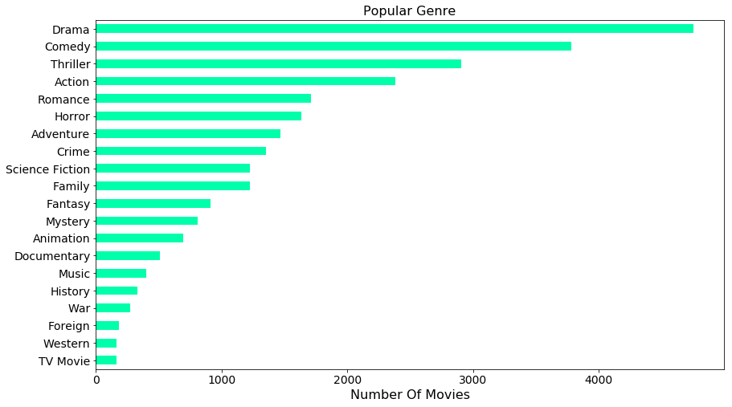

```python
#plotting the most frequent appeared genres

#sorting the counted genres
genre_count.sort_values(ascending = True, inplace = True)

#drawing the graph horizontally based on genre_count values
Pop_gen = genre_count.plot.barh(color = '#00FFAA', fontsize = 14)

#labeling the title for the graph
plt.title('Popular Genre', fontsize='16')

#Labeling the x-axis
plt.xlabel('Number Of Movies', color = 'black', fontsize = '16')

#figure size
Pop_gen.figure.set_size_inches(14, 8)
plt.show()
```

### Most Profitable Movie

> To analyze the most profitable movie I used the function max_min that return the maximum value of the column specified.

#### Function max_min:

> The function max_min that in a column as a parameter and it uses the built-in panda function idxmax() that returns the index of the maximum value in the column. Assign the index to the variable max_v and it is later use to find the row with the corresponding index. Same process is repeated for the min value but with idxmin() instead. After both rown have been extracted we use de concat function to stich them together and built a temporary dataframe with information we need.

```python
#defining the function max_min that get the max and minimus value from the column specified

def max_min(column):
    # Max profit
    max_v = df[column].idxmax()
    max_v = df.loc[max_v]

    # Min profit
    min_v = df[column].idxmin()
    min_v = df.loc[min_v]

    #Concat the to columns to make a single dataframe
    df_info = pd.concat([max_v, min_v], axis=1)

    return df_info

#calling the function
max_min('profit')
```

|  | 1386 | 2244 |
| --- | --- | --- |
| id | 19995 | 46528 |
| original_title | Avatar | The Warrior's Way |
| director | James Cameron | Sngmoo Lee |
| runtime | 162 | 100 |
| genres | Action\|Adventure\|Fantasy\|Science Fiction | Adventure\|Fantasy\|Action\|Western\|Thriller |
| budget | 237000000 | 425000000 |
| revenue | 2781505847 | 11087569 |
| profit | 2544505847 | -413912431 |
| release_date | 2009-12-10 00:00:00 | 2010-12-02 00:00:00 |
| vote_average | 7.1 | 6.4 |

## Do Movies with Higher Budget Perform Better

> > - **A** - More Votes
> > - **B** - More Profit

A

```
Text(0,0.5,'Budget')
```

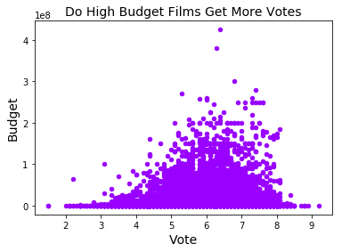

```python
budget_vote = df.plot(x='vote_average', y='budget', color = '#9900FF', kind='scatter')

plt.title('Do High Budget Films Get More Votes', fontsize='14')
budget_vote.set_xlabel('Vote', fontsize='14')
budget_vote.set_ylabel('Budget', fontsize='14')
```

```
Text(0,0.5,'Budget')
```

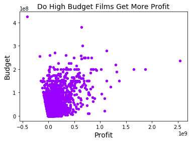

```python
budget_prof = df.plot(x='profit', y='budget', color = '#9900FF', kind='scatter')

plt.title('Do High Budget Films Get More Profit', fontsize='14')
budget_prof.set_xlabel('Profit', fontsize='14')
budget_prof.set_ylabel('Budget', fontsize='14')
```

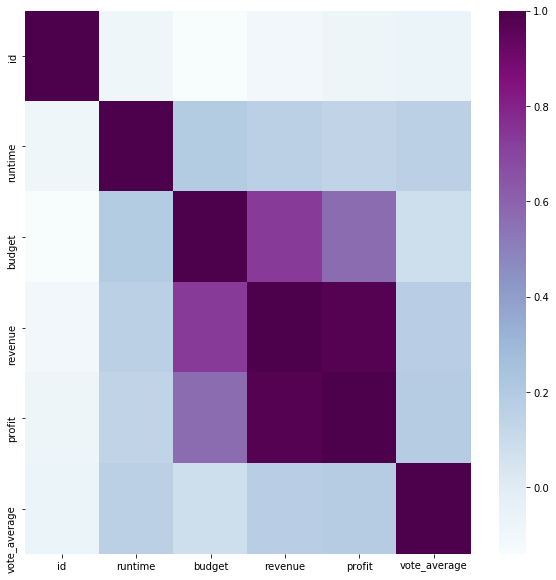

```python
plt.figure(figsize=(10, 10))
sns.heatmap(df.corr(), cmap="BuPu");
```

### What Word is Used The Most in Title

> > Here we are using the library wordcloud to do some text analysis in a trendy and interactive way. The words that are the boldest are the most used words within a given column in our case that is the movie title column of the data frame (df.original_title).

#### The most popular word are:

> > - **Man**
> > - **Love**
> > - **Dead**
> > - **Day**
> > - **Night**
> > - **Movie**
> > - **II**

```python
title_corpus = ' '.join(df['original_title'])
```

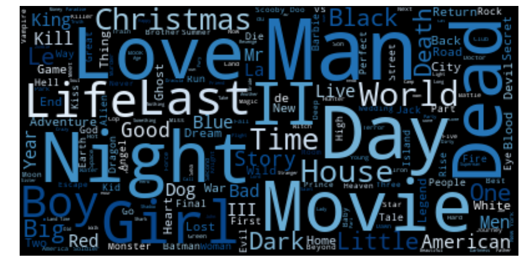

```python
wordcloud = WordCloud(background_color="Black", colormap="Blues").generate(title_corpus)
plt.figure(figsize=(15,15))# Display the generated image:
plt.imshow(wordcloud, interpolation='bilinear')
plt.axis("off")
plt.show();
```

## Conclusions

### Most popular genre

> The most popular genre by far is Drama only follow up by comedy.

### Most profitable movie

> The most profitable movie in this dataset is Avatar with a profit of 2.5 billion dollars.

### What word is the most popular among titles (EXTRA)

> The most popular word are:
> - Man
> - Love
> - Dead
> - Day
> - Night
> - Movie
> - II

## Limitations

> This is a brief data analysis however it is worth investigation into other interestion point and question like correlation between director and popularity in a film. There are also some outlier in the budget and profit column worth investigating.

## Submitting your Project

```python
from subprocess import call
call(['python', '-m', 'nbconvert', 'Investigate_a_Dataset.ipynb'])
```